# Optimal Treatment Analysis

## Outcome Variable

**Outcome Variable:** whz

## Predictor Variables

**Intervention Variable:** mwtkg

**Adjustment Set:**

- arm
- W_mage
- W_fage
- meducyrs
- feducyrs
- single
- brthmon
- delta_W_mage
- delta_W_fage
- delta_meducyrs
- delta_feducyrs
- delta_single
- delta_brthmon

## Stratifying Variables

The analysis was stratified on these variable(s):

- agecat
- studyid
- country

## Data Summary

| agecat | studyid | country | mwtkg | n_cell | n |
| --- | --- | --- | --- | --- | --- |
| Birth | ki0047075b-MAL-ED | BANGLADESH | >=58 kg | 46 | 233 |
| Birth | ki0047075b-MAL-ED | BANGLADESH | <52 kg | 144 | 233 |
| Birth | ki0047075b-MAL-ED | BANGLADESH | [52-58) kg | 43 | 233 |
| Birth | ki0047075b-MAL-ED | BRAZIL | >=58 kg | 117 | 176 |
| Birth | ki0047075b-MAL-ED | BRAZIL | <52 kg | 31 | 176 |
| Birth | ki0047075b-MAL-ED | BRAZIL | [52-58) kg | 28 | 176 |
| Birth | ki0047075b-MAL-ED | INDIA | >=58 kg | 36 | 195 |
| Birth | ki0047075b-MAL-ED | INDIA | <52 kg | 121 | 195 |
| Birth | ki0047075b-MAL-ED | INDIA | [52-58) kg | 38 | 195 |
| Birth | ki0047075b-MAL-ED | NEPAL | >=58 kg | 56 | 167 |
| Birth | ki0047075b-MAL-ED | NEPAL | <52 kg | 48 | 167 |
| Birth | ki0047075b-MAL-ED | NEPAL | [52-58) kg | 63 | 167 |
| Birth | ki0047075b-MAL-ED | PERU | >=58 kg | 97 | 269 |
| Birth | ki0047075b-MAL-ED | PERU | <52 kg | 104 | 269 |
| Birth | ki0047075b-MAL-ED | PERU | [52-58) kg | 68 | 269 |
| Birth | ki0047075b-MAL-ED | SOUTH AFRICA | >=58 kg | 165 | 226 |
| Birth | ki0047075b-MAL-ED | SOUTH AFRICA | <52 kg | 23 | 226 |
| Birth | ki0047075b-MAL-ED | SOUTH AFRICA | [52-58) kg | 38 | 226 |
| Birth | ki0047075b-MAL-ED | TANZANIA, UNITED REPUBLIC OF | >=58 kg | 51 | 116 |
| Birth | ki0047075b-MAL-ED | TANZANIA, UNITED REPUBLIC OF | <52 kg | 37 | 116 |
| Birth | ki0047075b-MAL-ED | TANZANIA, UNITED REPUBLIC OF | [52-58) kg | 28 | 116 |
| Birth | ki1000304b-SAS-CompFeed | INDIA | >=58 kg | 12 | 162 |
| Birth | ki1000304b-SAS-CompFeed | INDIA | <52 kg | 124 | 162 |
| Birth | ki1000304b-SAS-CompFeed | INDIA | [52-58) kg | 26 | 162 |
| Birth | ki1017093-NIH-Birth | BANGLADESH | >=58 kg | 2 | 28 |
| Birth | ki1017093-NIH-Birth | BANGLADESH | <52 kg | 23 | 28 |
| Birth | ki1017093-NIH-Birth | BANGLADESH | [52-58) kg | 3 | 28 |
| Birth | ki1017093c-NIH-Crypto | BANGLADESH | >=58 kg | 4 | 23 |
| Birth | ki1017093c-NIH-Crypto | BANGLADESH | <52 kg | 17 | 23 |
| Birth | ki1017093c-NIH-Crypto | BANGLADESH | [52-58) kg | 2 | 23 |

[output cut: 93 more lines]

The following strata were considered:

- agecat: 24 months, studyid: ki0047075b-MAL-ED, country: BANGLADESH
- agecat: 24 months, studyid: ki0047075b-MAL-ED, country: BRAZIL
- agecat: 24 months, studyid: ki0047075b-MAL-ED, country: INDIA
- agecat: 24 months, studyid: ki0047075b-MAL-ED, country: NEPAL
- agecat: 24 months, studyid: ki0047075b-MAL-ED, country: PERU
- agecat: 24 months, studyid: ki0047075b-MAL-ED, country: SOUTH AFRICA
- agecat: 24 months, studyid: ki0047075b-MAL-ED, country: TANZANIA, UNITED REPUBLIC OF
- agecat: 24 months, studyid: ki1017093-NIH-Birth, country: BANGLADESH
- agecat: 24 months, studyid: ki1017093b-PROVIDE, country: BANGLADESH
- agecat: 24 months, studyid: ki1017093c-NIH-Crypto, country: BANGLADESH
- agecat: 24 months, studyid: ki1066203-TanzaniaChild2, country: TANZANIA, UNITED REPUBLIC OF
- agecat: 24 months, studyid: ki1119695-PROBIT, country: BELARUS
- agecat: 24 months, studyid: ki1126311-ZVITAMBO, country: ZIMBABWE
- agecat: 24 months, studyid: ki1148112-LCNI-5, country: MALAWI
- agecat: 6 months, studyid: ki0047075b-MAL-ED, country: BANGLADESH
- agecat: 6 months, studyid: ki0047075b-MAL-ED, country: BRAZIL
- agecat: 6 months, studyid: ki0047075b-MAL-ED, country: INDIA
- agecat: 6 months, studyid: ki0047075b-MAL-ED, country: NEPAL
- agecat: 6 months, studyid: ki0047075b-MAL-ED, country: PERU
- agecat: 6 months, studyid: ki0047075b-MAL-ED, country: SOUTH AFRICA
- agecat: 6 months, studyid: ki0047075b-MAL-ED, country: TANZANIA, UNITED REPUBLIC OF
- agecat: 6 months, studyid: ki1000304b-SAS-CompFeed, country: INDIA
- agecat: 6 months, studyid: ki1017093-NIH-Birth, country: BANGLADESH
- agecat: 6 months, studyid: ki1017093b-PROVIDE, country: BANGLADESH
- agecat: 6 months, studyid: ki1017093c-NIH-Crypto, country: BANGLADESH
- agecat: 6 months, studyid: ki1066203-TanzaniaChild2, country: TANZANIA, UNITED REPUBLIC OF
- agecat: 6 months, studyid: ki1119695-PROBIT, country: BELARUS
- agecat: 6 months, studyid: ki1126311-ZVITAMBO, country: ZIMBABWE
- agecat: 6 months, studyid: ki1148112-LCNI-5, country: MALAWI
- agecat: Birth, studyid: ki0047075b-MAL-ED, country: BANGLADESH
- agecat: Birth, studyid: ki0047075b-MAL-ED, country: BRAZIL
- agecat: Birth, studyid: ki0047075b-MAL-ED, country: INDIA
- agecat: Birth, studyid: ki0047075b-MAL-ED, country: NEPAL
- agecat: Birth, studyid: ki0047075b-MAL-ED, country: PERU
- agecat: Birth, studyid: ki0047075b-MAL-ED, country: SOUTH AFRICA
- agecat: Birth, studyid: ki0047075b-MAL-ED, country: TANZANIA, UNITED REPUBLIC OF
- agecat: Birth, studyid: ki1000304b-SAS-CompFeed, country: INDIA
- agecat: Birth, studyid: ki1017093-NIH-Birth, country: BANGLADESH
- agecat: Birth, studyid: ki1017093c-NIH-Crypto, country: BANGLADESH
- agecat: Birth, studyid: ki1119695-PROBIT, country: BELARUS
- agecat: Birth, studyid: ki1126311-ZVITAMBO, country: ZIMBABWE

### Dropped Strata

Some strata were dropped due to rare outcomes:

- agecat: Birth, studyid: ki1017093-NIH-Birth, country: BANGLADESH
- agecat: Birth, studyid: ki1017093c-NIH-Crypto, country: BANGLADESH
- agecat: 24 months, studyid: ki1066203-TanzaniaChild2, country: TANZANIA, UNITED REPUBLIC OF

## Methods Detail

We’re interested in the causal parameters $E[Y_a]$ for all values of $a \in \mathcal{A}$. These parameters represent the mean outcome if, possibly contrary to fact, we intervened to set all units to have $A=a$. Under the randomization and positivity assumptions, these are identified by the statistical parameters $\psi_a=E_W[E_{Y|A,W}(Y|A=a,W)]$. In addition, we’re interested in the mean of $Y$, $E[Y]$ under no intervention (the observed mean). We will estimate these parameters by using SuperLearner to fit the relevant likelihood factors – $E_{Y|A,W}(Y|A=a,W)$ and $p(A=a|W)$, and then updating our likelihood fit using a joint TMLE.

For unadjusted analyses ($W=\{\}$), initial likelihoods were estimated using Lrnr_glm to estimate the simple $E(Y|A)$ and Lrnr_mean to estimate $p(A)$. For adjusted analyses, a small library containing Lrnr_glmnet, Lrnr_xgboost, and Lrnr_mean was used.

# Results Detail

## Results Plots

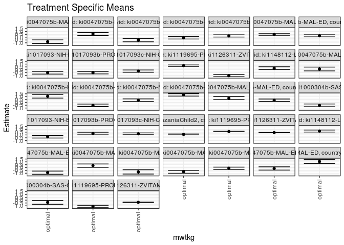

## Results Table

### Parameter: TSM

| agecat | studyid | country | intervention_level | baseline_level | estimate | ci_lower | ci_upper |
| --- | --- | --- | --- | --- | --- | --- | --- |
| Birth | ki0047075b-MAL-ED | BANGLADESH | optimal | observed | -0.9043794 | -1.1874715 | -0.6212872 |
| Birth | ki0047075b-MAL-ED | BRAZIL | optimal | observed | 0.3326320 | 0.0376747 | 0.6275893 |
| Birth | ki0047075b-MAL-ED | INDIA | optimal | observed | -0.7698277 | -1.1479382 | -0.3917172 |
| Birth | ki0047075b-MAL-ED | NEPAL | optimal | observed | -0.7477458 | -1.0078457 | -0.4876459 |
| Birth | ki0047075b-MAL-ED | PERU | optimal | observed | -0.1275334 | -0.3281667 | 0.0731000 |
| Birth | ki0047075b-MAL-ED | SOUTH AFRICA | optimal | observed | -0.1619871 | -0.4490150 | 0.1250408 |
| Birth | ki0047075b-MAL-ED | TANZANIA, UNITED REPUBLIC OF | optimal | observed | 1.0586933 | 0.7235082 | 1.3938784 |
| Birth | ki1000304b-SAS-CompFeed | INDIA | optimal | observed | -0.3896675 | -0.7287322 | -0.0506027 |
| Birth | ki1119695-PROBIT | BELARUS | optimal | observed | -1.1174217 | -1.3291036 | -0.9057397 |
| Birth | ki1126311-ZVITAMBO | ZIMBABWE | optimal | observed | -0.3792889 | -0.4209043 | -0.3376736 |
| 6 months | ki0047075b-MAL-ED | BANGLADESH | optimal | observed | 0.1319876 | -0.1991645 | 0.4631398 |
| 6 months | ki0047075b-MAL-ED | BRAZIL | optimal | observed | 1.0722459 | 0.7498402 | 1.3946517 |
| 6 months | ki0047075b-MAL-ED | INDIA | optimal | observed | -0.5198466 | -0.7379063 | -0.3017869 |
| 6 months | ki0047075b-MAL-ED | NEPAL | optimal | observed | 0.3787688 | 0.1472703 | 0.6102672 |
| 6 months | ki0047075b-MAL-ED | PERU | optimal | observed | 1.3147936 | 1.1071035 | 1.5224837 |
| 6 months | ki0047075b-MAL-ED | SOUTH AFRICA | optimal | observed | 0.7454166 | 0.4713257 | 1.0195076 |
| 6 months | ki0047075b-MAL-ED | TANZANIA, UNITED REPUBLIC OF | optimal | observed | 0.3766057 | 0.1667226 | 0.5864888 |
| 6 months | ki1000304b-SAS-CompFeed | INDIA | optimal | observed | -0.5273353 | -0.7708603 | -0.2838102 |
| 6 months | ki1017093-NIH-Birth | BANGLADESH | optimal | observed | -0.3293965 | -0.5465512 | -0.1122417 |
| 6 months | ki1017093b-PROVIDE | BANGLADESH | optimal | observed | 0.2532770 | 0.0225482 | 0.4840059 |
| 6 months | ki1017093c-NIH-Crypto | BANGLADESH | optimal | observed | 0.1997566 | 0.0359125 | 0.3636007 |
| 6 months | ki1066203-TanzaniaChild2 | TANZANIA, UNITED REPUBLIC OF | optimal | observed | 0.0959890 | 0.0200953 | 0.1718827 |
| 6 months | ki1119695-PROBIT | BELARUS | optimal | observed | 0.6054346 | 0.5479124 | 0.6629567 |
| 6 months | ki1126311-ZVITAMBO | ZIMBABWE | optimal | observed | 0.4189973 | 0.3825562 | 0.4554384 |
| 6 months | ki1148112-LCNI-5 | MALAWI | optimal | observed | 0.6882412 | 0.5115410 | 0.8649414 |
| 24 months | ki0047075b-MAL-ED | BANGLADESH | optimal | observed | -0.8052382 | -1.1308243 | -0.4796521 |
| 24 months | ki0047075b-MAL-ED | BRAZIL | optimal | observed | 0.5631366 | 0.3011988 | 0.8250744 |
| 24 months | ki0047075b-MAL-ED | INDIA | optimal | observed | -0.5178622 | -0.8179538 | -0.2177707 |
| 24 months | ki0047075b-MAL-ED | NEPAL | optimal | observed | -0.1157180 | -0.3260329 | 0.0945969 |
| 24 months | ki0047075b-MAL-ED | PERU | optimal | observed | 0.2195877 | 0.0198815 | 0.4192938 |
| 24 months | ki0047075b-MAL-ED | SOUTH AFRICA | optimal | observed | 0.4763762 | 0.3371340 | 0.6156183 |
| 24 months | ki0047075b-MAL-ED | TANZANIA, UNITED REPUBLIC OF | optimal | observed | 0.2410874 | 0.0587986 | 0.4233763 |
| 24 months | ki1017093-NIH-Birth | BANGLADESH | optimal | observed | -0.5232654 | -0.7612081 | -0.2853226 |
| 24 months | ki1017093b-PROVIDE | BANGLADESH | optimal | observed | -0.5091783 | -0.7307155 | -0.2876411 |
| 24 months | ki1017093c-NIH-Crypto | BANGLADESH | optimal | observed | -0.2381526 | -0.4360243 | -0.0402810 |
| 24 months | ki1119695-PROBIT | BELARUS | optimal | observed | 0.7242389 | 0.5984793 | 0.8499984 |
| 24 months | ki1126311-ZVITAMBO | ZIMBABWE | optimal | observed | -1.0404632 | -1.2344123 | -0.8465141 |
| 24 months | ki1148112-LCNI-5 | MALAWI | optimal | observed | 0.2725649 | 0.0237644 | 0.5213654 |

### Parameter: E(Y)

| agecat | studyid | country | intervention_level | baseline_level | estimate | ci_lower | ci_upper |
| --- | --- | --- | --- | --- | --- | --- | --- |
| Birth | ki0047075b-MAL-ED | BANGLADESH | observed | observed | -0.9724464 | -1.1091046 | -0.8357881 |
| Birth | ki0047075b-MAL-ED | BRAZIL | observed | observed | 0.3832386 | 0.2044597 | 0.5620175 |
| Birth | ki0047075b-MAL-ED | INDIA | observed | observed | -1.0698974 | -1.2115847 | -0.9282102 |
| Birth | ki0047075b-MAL-ED | NEPAL | observed | observed | -0.9126946 | -1.0520834 | -0.7733058 |
| Birth | ki0047075b-MAL-ED | PERU | observed | observed | -0.0660967 | -0.1789362 | 0.0467429 |
| Birth | ki0047075b-MAL-ED | SOUTH AFRICA | observed | observed | -0.0346018 | -0.1831486 | 0.1139451 |
| Birth | ki0047075b-MAL-ED | TANZANIA, UNITED REPUBLIC OF | observed | observed | 0.7950000 | 0.5947353 | 0.9952647 |
| Birth | ki1000304b-SAS-CompFeed | INDIA | observed | observed | -0.2353086 | -0.4984656 | 0.0278483 |
| Birth | ki1119695-PROBIT | BELARUS | observed | observed | -1.1441825 | -1.3547365 | -0.9336286 |
| Birth | ki1126311-ZVITAMBO | ZIMBABWE | observed | observed | -0.4819806 | -0.5108811 | -0.4530800 |
| 6 months | ki0047075b-MAL-ED | BANGLADESH | observed | observed | -0.1397960 | -0.2688682 | -0.0107238 |
| 6 months | ki0047075b-MAL-ED | BRAZIL | observed | observed | 0.9644952 | 0.7999744 | 1.1290160 |
| 6 months | ki0047075b-MAL-ED | INDIA | observed | observed | -0.6987943 | -0.8241325 | -0.5734561 |
| 6 months | ki0047075b-MAL-ED | NEPAL | observed | observed | 0.1110452 | -0.0202712 | 0.2423616 |
| 6 months | ki0047075b-MAL-ED | PERU | observed | observed | 1.0563787 | 0.9342938 | 1.1784635 |
| 6 months | ki0047075b-MAL-ED | SOUTH AFRICA | observed | observed | 0.5290428 | 0.3750394 | 0.6830463 |
| 6 months | ki0047075b-MAL-ED | TANZANIA, UNITED REPUBLIC OF | observed | observed | 0.5170513 | 0.3872178 | 0.6468847 |
| 6 months | ki1000304b-SAS-CompFeed | INDIA | observed | observed | -0.6674586 | -0.8042294 | -0.5306877 |
| 6 months | ki1017093-NIH-Birth | BANGLADESH | observed | observed | -0.4389101 | -0.5279432 | -0.3498771 |
| 6 months | ki1017093b-PROVIDE | BANGLADESH | observed | observed | -0.2079891 | -0.2925599 | -0.1234183 |
| 6 months | ki1017093c-NIH-Crypto | BANGLADESH | observed | observed | 0.0297622 | -0.0491685 | 0.1086930 |
| 6 months | ki1066203-TanzaniaChild2 | TANZANIA, UNITED REPUBLIC OF | observed | observed | 0.0780261 | 0.0247830 | 0.1312691 |
| 6 months | ki1119695-PROBIT | BELARUS | observed | observed | 0.5834072 | 0.5254491 | 0.6413653 |
| 6 months | ki1126311-ZVITAMBO | ZIMBABWE | observed | observed | 0.2953392 | 0.2687669 | 0.3219114 |
| 6 months | ki1148112-LCNI-5 | MALAWI | observed | observed | 0.4518399 | 0.3806212 | 0.5230586 |
| 24 months | ki0047075b-MAL-ED | BANGLADESH | observed | observed | -0.8208255 | -0.9429246 | -0.6987264 |
| 24 months | ki0047075b-MAL-ED | BRAZIL | observed | observed | 0.4282738 | 0.2252365 | 0.6313111 |
| 24 months | ki0047075b-MAL-ED | INDIA | observed | observed | -0.9525664 | -1.0684455 | -0.8366872 |
| 24 months | ki0047075b-MAL-ED | NEPAL | observed | observed | -0.3764474 | -0.4898516 | -0.2630431 |
| 24 months | ki0047075b-MAL-ED | PERU | observed | observed | 0.1199005 | -0.0000331 | 0.2398341 |
| 24 months | ki0047075b-MAL-ED | SOUTH AFRICA | observed | observed | 0.4096154 | 0.2902946 | 0.5289362 |
| 24 months | ki0047075b-MAL-ED | TANZANIA, UNITED REPUBLIC OF | observed | observed | 0.0500935 | -0.0748234 | 0.1750103 |
| 24 months | ki1017093-NIH-Birth | BANGLADESH | observed | observed | -0.9115790 | -1.0095022 | -0.8136559 |
| 24 months | ki1017093b-PROVIDE | BANGLADESH | observed | observed | -0.8864991 | -0.9695215 | -0.8034768 |
| 24 months | ki1017093c-NIH-Crypto | BANGLADESH | observed | observed | -0.6103502 | -0.7050157 | -0.5156847 |
| 24 months | ki1119695-PROBIT | BELARUS | observed | observed | 0.6877387 | 0.5737746 | 0.8017027 |
| 24 months | ki1126311-ZVITAMBO | ZIMBABWE | observed | observed | -1.1865133 | -1.2873598 | -1.0856668 |
| 24 months | ki1148112-LCNI-5 | MALAWI | observed | observed | -0.0467082 | -0.1287046 | 0.0352882 |

### Parameter: PAR

| agecat | studyid | country | intervention_level | baseline_level | estimate | ci_lower | ci_upper |
| --- | --- | --- | --- | --- | --- | --- | --- |
| Birth | ki0047075b-MAL-ED | BANGLADESH | optimal | observed | -0.0680670 | -0.3315880 | 0.1954540 |
| Birth | ki0047075b-MAL-ED | BRAZIL | optimal | observed | 0.0506066 | -0.1638114 | 0.2650247 |
| Birth | ki0047075b-MAL-ED | INDIA | optimal | observed | -0.3000697 | -0.6371706 | 0.0370311 |
| Birth | ki0047075b-MAL-ED | NEPAL | optimal | observed | -0.1649488 | -0.3682253 | 0.0383278 |
| Birth | ki0047075b-MAL-ED | PERU | optimal | observed | 0.0614367 | -0.1069686 | 0.2298420 |
| Birth | ki0047075b-MAL-ED | SOUTH AFRICA | optimal | observed | 0.1273853 | -0.1030875 | 0.3578582 |
| Birth | ki0047075b-MAL-ED | TANZANIA, UNITED REPUBLIC OF | optimal | observed | -0.2636933 | -0.5513932 | 0.0240066 |
| Birth | ki1000304b-SAS-CompFeed | INDIA | optimal | observed | 0.1543588 | -0.2299737 | 0.5386914 |
| Birth | ki1119695-PROBIT | BELARUS | optimal | observed | -0.0267609 | -0.0544280 | 0.0009063 |
| Birth | ki1126311-ZVITAMBO | ZIMBABWE | optimal | observed | -0.1026916 | -0.1321773 | -0.0732060 |
| 6 months | ki0047075b-MAL-ED | BANGLADESH | optimal | observed | -0.2717836 | -0.5745725 | 0.0310053 |
| 6 months | ki0047075b-MAL-ED | BRAZIL | optimal | observed | -0.1077507 | -0.3852538 | 0.1697524 |
| 6 months | ki0047075b-MAL-ED | INDIA | optimal | observed | -0.1789477 | -0.3988534 | 0.0409580 |
| 6 months | ki0047075b-MAL-ED | NEPAL | optimal | observed | -0.2677236 | -0.4553424 | -0.0801047 |
| 6 months | ki0047075b-MAL-ED | PERU | optimal | observed | -0.2584149 | -0.4237578 | -0.0930720 |
| 6 months | ki0047075b-MAL-ED | SOUTH AFRICA | optimal | observed | -0.2163738 | -0.4437419 | 0.0109943 |
| 6 months | ki0047075b-MAL-ED | TANZANIA, UNITED REPUBLIC OF | optimal | observed | 0.1404456 | -0.0511599 | 0.3320510 |
| 6 months | ki1000304b-SAS-CompFeed | INDIA | optimal | observed | -0.1401233 | -0.3268504 | 0.0466038 |
| 6 months | ki1017093-NIH-Birth | BANGLADESH | optimal | observed | -0.1095137 | -0.3155121 | 0.0964847 |
| 6 months | ki1017093b-PROVIDE | BANGLADESH | optimal | observed | -0.4612661 | -0.6696956 | -0.2528366 |
| 6 months | ki1017093c-NIH-Crypto | BANGLADESH | optimal | observed | -0.1699944 | -0.3124139 | -0.0275749 |
| 6 months | ki1066203-TanzaniaChild2 | TANZANIA, UNITED REPUBLIC OF | optimal | observed | -0.0179629 | -0.0710287 | 0.0351029 |
| 6 months | ki1119695-PROBIT | BELARUS | optimal | observed | -0.0220274 | -0.0352755 | -0.0087793 |
| 6 months | ki1126311-ZVITAMBO | ZIMBABWE | optimal | observed | -0.1236581 | -0.1496265 | -0.0976897 |
| 6 months | ki1148112-LCNI-5 | MALAWI | optimal | observed | -0.2364013 | -0.4035144 | -0.0692882 |
| 24 months | ki0047075b-MAL-ED | BANGLADESH | optimal | observed | -0.0155872 | -0.3101297 | 0.2789552 |
| 24 months | ki0047075b-MAL-ED | BRAZIL | optimal | observed | -0.1348628 | -0.2924819 | 0.0227563 |
| 24 months | ki0047075b-MAL-ED | INDIA | optimal | observed | -0.4347041 | -0.7116960 | -0.1577123 |
| 24 months | ki0047075b-MAL-ED | NEPAL | optimal | observed | -0.2607294 | -0.4275105 | -0.0939482 |
| 24 months | ki0047075b-MAL-ED | PERU | optimal | observed | -0.0996872 | -0.2811754 | 0.0818011 |
| 24 months | ki0047075b-MAL-ED | SOUTH AFRICA | optimal | observed | -0.0667608 | -0.1447367 | 0.0112151 |
| 24 months | ki0047075b-MAL-ED | TANZANIA, UNITED REPUBLIC OF | optimal | observed | -0.1909940 | -0.3458065 | -0.0361814 |
| 24 months | ki1017093-NIH-Birth | BANGLADESH | optimal | observed | -0.3883137 | -0.6130110 | -0.1636164 |
| 24 months | ki1017093b-PROVIDE | BANGLADESH | optimal | observed | -0.3773209 | -0.5741872 | -0.1804546 |
| 24 months | ki1017093c-NIH-Crypto | BANGLADESH | optimal | observed | -0.3721976 | -0.5423525 | -0.2020426 |
| 24 months | ki1119695-PROBIT | BELARUS | optimal | observed | -0.0365002 | -0.0843070 | 0.0113066 |
| 24 months | ki1126311-ZVITAMBO | ZIMBABWE | optimal | observed | -0.1460501 | -0.3153665 | 0.0232663 |
| 24 months | ki1148112-LCNI-5 | MALAWI | optimal | observed | -0.3192731 | -0.5495531 | -0.0889930 |